# DU High throughput sequencing and rare diseases - Introduction to Ensembl Genome Browser/Biomart

Jean Muller$^{1}$ - jeanmuller@unistra.fr; Stephanie Le Gras$^{2}$ - slegras@unistra.fr

2026 January 21st

$^1$ UMR_S 1112, Laboratoire de Génétique Médicale, Laboratoire de Diagnostic Génétique (CHU Strasbourg)

$^2$ Plateau technique de biologie moléculaire et bioinformatique, INCI - LNCA, Strasbourg, Équipe Modulation épigénétique des processus neurodégénératifs, LNCA, Strasbourg

# 1 - Practical session: Ensembl Genome Browser

## 1.1 - Question

- What is the assembly version of the human genome available on the current Ensembl release?

**Show answer**

[figure not shown]

- How many coding genes does the Human genome contain in the current Ensembl release (v115)?

**Show answer**

[figure not shown]

- How many coding genes does the Human genome contain in the previous assembly (GRCh37 - Ensembl v75)?

**Show answer**

[figure not shown]

## 1.2 - Question

- Find out the size of the human chromosome 4 for assembly hg19 (GRCh37).

**Show answer**

[figure not shown]

## 1.3 - Question

**Go back to http://ensembl.org.**

- What is the version of the genome assembly of the Naked mole-rat (female)? (Heterocephalus glaber)

**Show answer**

[figure not shown]

- How many coding genes does the Naked mole-rat female genome contain?

**Show answer**

[figure not shown]

## 1.4 - Question

- How many alternative transcript gene BBS5 has (Human)

**Show answer**

[figure not shown]

- How many exons does transcript BBS5-205 have?

**Show answer**

[figure not shown]

- How many coding exons?

**Show answer**

[figure not shown]

Comment – Go back to the “Gene: BBS5” tab and have a look at the colors of transcripts BBS5-201 and BBS5-202 in the genome browser view

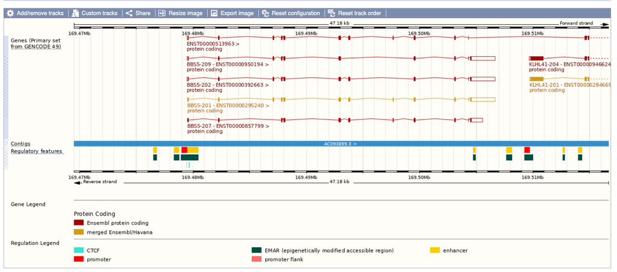

## 1.5 - Question

- Retrieve this page

[figure not shown]

**Show answer**

[figure not shown]

## 1.6 - Question

- Retrieve this page

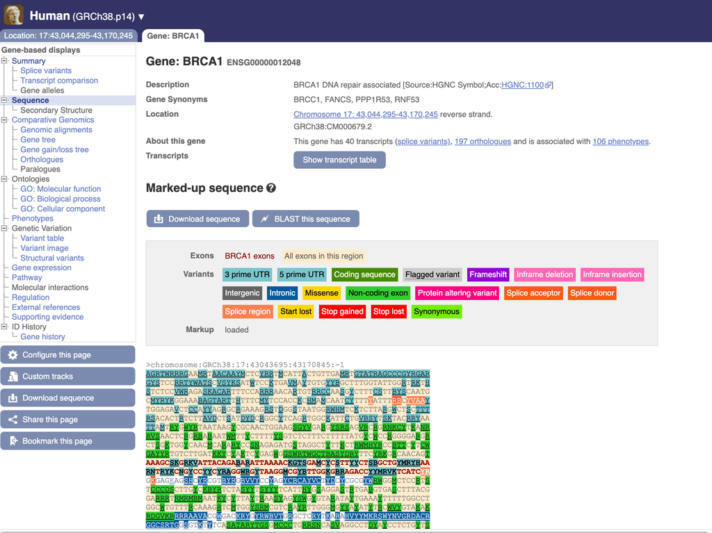

**Show answer**

- Click on « configure this page » (left-bottom menu)
  - Select Yes for « Show variations: »

[figure not shown]

## 1.7 - Question

Display RNAseq data for breast and skeletal muscle in the genome browser (in BRCA1 gene region).

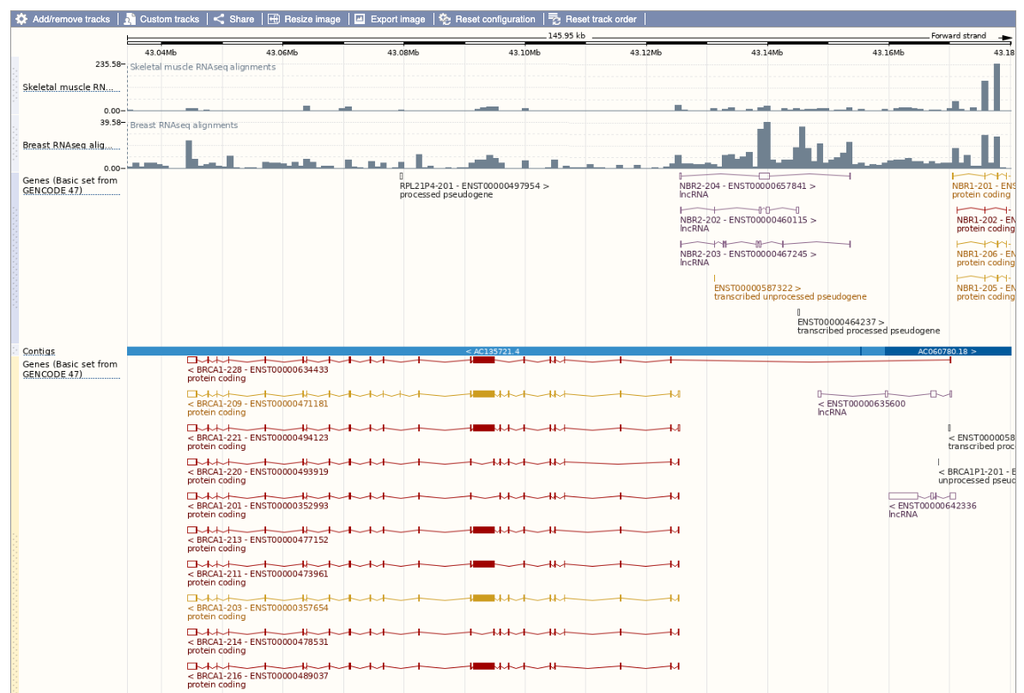

**Show answer**

[figure not shown]

[figure not shown]

# 2 - Practical session: Biomart

## 2.1 - Retrieve information for 1 gene : IDH1

### 2.1.1 - Question

Using Ensembl/BioMart, retrieve all transcripts IDs and the gene ID of IDH1 gene (human). How many transcripts the gene IDH1 has? Use Ensembl Gene v115, for Human GRCh38.p14:

- Click on Filters :
  - Expand the GENE section
  - Select « Input external references ID list »
  - Select HGNC symbol(s) in the drop down menu
  - Enter IDH1 in the text box
- Click on Attributes :
  - Select “Features” (top panel, selected by default)
  - Select Gene stable ID, Transcript stable ID, Gene Name

**Show answer**

- Click on Filters (left panel)
  - Expand the “GENE” section
  - Select “Input external references ID list”, select “Gene Name(s)” in the drop down list and enter IDH1.
  - Click on Count in the top left panel . You should get 1 / 86369 Genes.
  - Click on Attributes (left menu)
  - Select “Features” (selected by default)
  - Select Gene stable ID, Transcript stable ID, Gene Name
  - Click on Results (top left menu)

**34 transcripts are found**

### 2.1.2 - Question

Extract all exon sequences of the IDH1 gene in fasta format. Headers will contain the Gene names, Transcript stable IDs and Exon stable IDs.

**Show answer**

You can leave the Dataset and Filters the same, and go directly to the Attributes section:

- Click on Attributes (left panel)
  - Select “Sequences”
  - Expand the SEQUENCES section
  - Select Exon sequences
  - Expand “Header Information”
  - Unselect “Gene stable ID” (Gene Information)
  - Select Gene name (Gene Information), Transcript stable ID (Transcript Information) and Exon stable ID (Exon Information).
  - Click on Results

### 2.1.3 - Question

Extract all coding sequences of the IDH1 gene in fasta format. Headers will contain the Transcript stable IDs and Exon stable IDs.

**Show answer**

You can leave the Dataset and Filters the same, and go directly to the Attributes section:

- Click on Attributes (left panel)
  - In the SEQUENCES section: select Coding sequence
  - In the “Header Information”: unselect Gene name (Gene Information) and keep Transcript stable ID (Transcript Information) and Exon stable IDs (Exon Information) selected.
  - Click on Results

### 2.1.4 - Question

Retrieve GO-terms associated to the IDH1 gene (select GO Term Name, GO domain and GO Term Accession along with Gene stable ID, Transcript stable ID and Gene Name).

**Show answer**

You can leave the Dataset and Filters the same, and go directly to the Attributes section:

- Click on Attributes (left panel)
  - Select “Features” (selected by default)
  - In the GENE section: Gene stable ID, Transcript stable ID and Gene Name should be selected
  - Expand the EXTERNAL section
  - Select GO Term Name, GO domain and GO Term Accession
  - Click on Results

### 2.1.5 - Question

Retrieve the germline variations found in this gene. Annotations to be found:

- Variant Name,
- Variant Alleles,
- Minor allele frequency,
- Chromosome/scaffold name,
- Chromosome/scaffold position start (bp),
- Chromosome/scaffold position end (bp),
- Variant Consequence along with Gene stable ID,
- Transcript stable ID
- Gene Name

**Show answer**

You can leave the Dataset and Filters the same, and go directly to the Attributes section:

- Click on Attributes (left panel)
  - Select “Variant (Germline)”
  - In the GENE section: Gene stable ID, Transcript stable ID and Gene Name should be selected
  - Expand the GERMLINE VARIANT INFORMATION section
  - Select:
    - Variant Name,
    - Variant Alleles,
    - Minor allele frequency,
    - Chromosome/scaffold name,
    - Chromosome /scaffold position start (bp),
    - Chromosome/scaffold position end (bp),
    - Variant Consequence
  - Click on Results

## 2.2 - Retrieve information for many genes

We have run an RNA-seq experiment and we have extracted upregulated genes. We are using RNAseq data from :

*Strub, T., Giuliano, S., Ye, T., Bonet, C., Keime, C., Kobi, D., Le Gras, S., Cormont, M., Ballotti, R., and Bertolotto, C. (2011). Essential role of microphthalmia transcription factor for DNA replication, mitosis and genomic stability in melanoma. Oncogene 30, 2319–2332.*

In this study, they compared the transcriptome in melanoma cell lines between cells with an siRNA against MITF or an siRNA against Luciferase (used as a control). The data are given as a TSV (Tab-Separated Values) file which contain the number of reads per genes. Genes are identified by their Ensembl gene IDs.

Data have been analyzed using the **Human genome hg38/GRCh38 - Ensembl v95.**

Here are the different column of the file to be analyzed:

- Gene id | Ensembl gene ID |
- siLuc2 | Raw read counts - control - 1st biological replicate |
- siLuc3 | Raw read counts - control - 2nd biological replicate |
- siMitf3 | Raw read counts - siMITF - 1st biological replicate |
- siMitf4 | Raw read counts - siMITF - 2nd biological replicate |
- norm.siLuc2 | Normalized read counts - control - 1st biological replicate |
- norm.siLuc3 | Normalized read counts - control - 2nd biological replicate |
- norm.siMitf3 | Normalized read counts - siMITF - 1st biological replicate |
- norm.siMitf4 | Normalized read counts - siMITF - 2nd biological replicate |
- … | … |

### 2.2.1 - Question

Download the file [simitfvssiluc-up.tsv](https://seafile.igbmc.fr/f/5ba9c86a747043bca289/?dl=1) to extract gene annotations using Ensembl/BioMart for those genes. Use the column Gene ID to extract annotations. Annotations to extract are:

- gene IDs
- chromosome
- start of gene
- end of gene
- strand
- Associated Gene Name
- gene type

**Show answer**

In Ensembl/BioMart, create a new request using current version of Ensembl. How many genes are lost between/have changed between Ensembl v95 and current version?

### 2.2.2 - Question

You want to run a de novo motif discovery on all promoters of the upregulated genes (the ones from the file siMitfvssiLuc.up.txt). Extract the promoter sequences of all up-regulated genes: retrieve the 200nt upstream of the transcripts of these genes.

**Show answer**

Don’t change Dataset and Filters – simply click on Attributes.

- Click on Attributes (left panel)
  - Select “Sequences”
  - Expand the SEQUENCES section
  - Select Flank (Transcript) and enter 200 in the Upstream flank text box
  - Expand the Header information section
  - Select, in addition to the default selected attributes, Description and Associated Gene Name

**TIPS**

Flank (Transcript) will give the flanks for all transcripts of a gene with multiple transcripts. Flank (Gene) will give the flanks for one possible transcript in a gene (the most 5’ coordinates for upstream flanking).

## 2.3 - Retrieve information using genomic coordinates

### 2.3.1 - Question

How many genes are located in the genomic region: 2:208226227-208276270.

**Show answer**

In Ensembl/BioMart, create a new request:

- Click on Filters (left panel)
  - Expand the REGION section
  - Select “Multiple Chromosomal Regions” and enter 2:208226227:208276270 in the text box
  - Click on Count

** 4 genes are found**

### 2.3.2 - Question

Extract the coordinates of all human genes located on chromosomes (exclude scaffolds). Information to extract for each gene:

- Gene stable ID
- Chromosome/scaffold name
- Gene Start (bp)
- Gene End (bp)
- strand
- Gene Name

**Show answer**

In Ensembl/BioMart, create a new request (see slide 2.)

- Click on Filters (left panel)
  - Expand the REGION section
  - Select “Chromosome” and multiple select 1 -> MT (click and drag). This corresponds to 78691 / 86369 Genes
  - Click on Attributes (left panel)
  - Select “Features” (selected by default)
  - In GENE, select Gene stable ID, Chromosome/scaffold name, Gene Start (bp), Gene End (bp), strand and Gene Name
  - Click on Results

## 2.4 - Question

The following is a list of 11 IDs of human proteins from the [NCBI RefSeq database](http://www.ncbi.nlm.nih.gov/projects/RefSeq/):

- NP_001218
- NP_203125
- NP_203124
- NP_203126
- NP_001007233
- NP_150636
- NP_150635
- NP_001214
- NP_150637
- NP_150634
- NP_150649

Generate a list that shows to which Gene stable IDs and to which Gene names these RefSeq IDs correspond. Do these 11 proteins correspond to 11 genes?

**Show answer**

- Click New.
  - Choose the ENSEMBL Genes 115 database.
  - Choose the Homo sapiens genes (GRCh38.p14) dataset.
  - Click on Filters in the left panel.
  - Expand the GENE section by clicking on the + box.
  - Select ID list limit - RefSeq peptide ID(s) and enter the list of IDs in the text box (either comma separated or as a list).
  - HINT: You may have to scroll down the menu to see these.
  - Count shows 3 genes (remember one gene may have multiple splice variants coding for different proteins, that is the reason why these 11 do not correspond to 11 genes).
  - Click on Attributes in the left panel.
  - Select the Features attributes page.
  - Expand the External section by clicking on the + box.
  - Select Gene name and RefSeq Protein ID from the External References section.
  - Click the Results button on the toolbar.
  - Select View All rows as HTML or export all results to a file. Tick the box Unique results only.

## 2.5 - Bonus

Forrest et al performed a microarray analysis of peripheral blood mononuclear cell gene expression in benzene-exposed workers (Environ Health Perspect. 2005 June; 113(6): 801–807). The microarray used was the human Affymetrix U133A/B (also called U133 plus 2) GeneChip. The top 8 up-regulated probe-sets were:

- 207630_s_at
- 221840_at
- 219228_at
- 204924_at
- 227613_at
- 223454_at
- 228962_at
- 214696_at

### 2.5.1 - Question

Retrieve for the genes corresponding to these probe-sets the Gene and Transcript stable IDs as well as their Gene names and descriptions.

### 2.5.2 - Question

In order to be able to study these human genes in mouse, identify their mouse orthologues. Also retrieve the genomic coordinates of these orthologues.

**Show answer**

- You can leave the Dataset and Filters the same, and go directly to the Attributes section:
  - Click on Attributes in the left panel.
  - Select the Homologs attributes page.
  - Expand the GENE section by clicking on the + box.
  - Select Associated Gene Name.
  - Deselect Ensembl Transcript ID.
  - Expand the ORTHOLOGS section by clicking on the + box.
  - Select Mouse Ensembl Gene stable ID, Mouse chromosome/scaffold name, Mouse chromosome/scaffold Start (bp) and Mouse chromosome/scaffold End (bp).
  - Click the Results button on the toolbar.
  - Check the box Unique results only. Select View All rows as HTML or export all results to a file.

**Your results should show that for most of the human genes has least one mouse orthologue.**

# 3 - Credits

Some exercices are taken from [Ensembl tutorials](http://www.ebi.ac.uk/seqdb/confluence/display/ENSEXT/Ensembl+exercises).

# 4 - Ensembl mirror

http://useast.ensembl.org/index.html